# Lab 3

Brad Anderson

February 1, 2018

#### Bootstrapping

```r
library(tidyverse)
library(boot)
library(nlstools)
penguins <- read_csv("H:/Week 3 Bootstrapping NOLS/penguins.csv")
CellGrowth <- read_csv("H:/Week 3 Bootstrapping NOLS/CellGrowth.csv")
```

Make a vector of values that we will bootstrap.

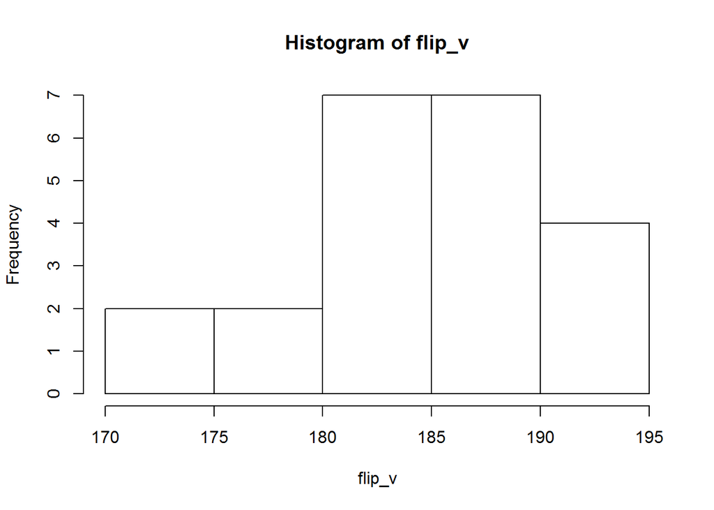

```r
flip <- penguins %>%
  filter(sex == "FEMALE") %>%
  select(flipper_length)

flip_v <- flip$flipper_length

hist(flip_v)
```

C. Create a function to calculate the means of the bootstrap samples

```r
mean_fun <- function (x, i) {mean(x[i])} #i are the different bootstrap samples
```

4. bootstrap flip_v

```r
boot_10 <- boot(flip_v, mean_fun, R = 10)
boot_10$t
```

```
##           [,1]
##  [1,] 184.4545
##  [2,] 187.1818
##  [3,] 184.4545
##  [4,] 186.0909
##  [5,] 186.0909
##  [6,] 185.5455
##  [7,] 184.0909
##  [8,] 184.8636
##  [9,] 186.3182
## [10,] 182.7727
```

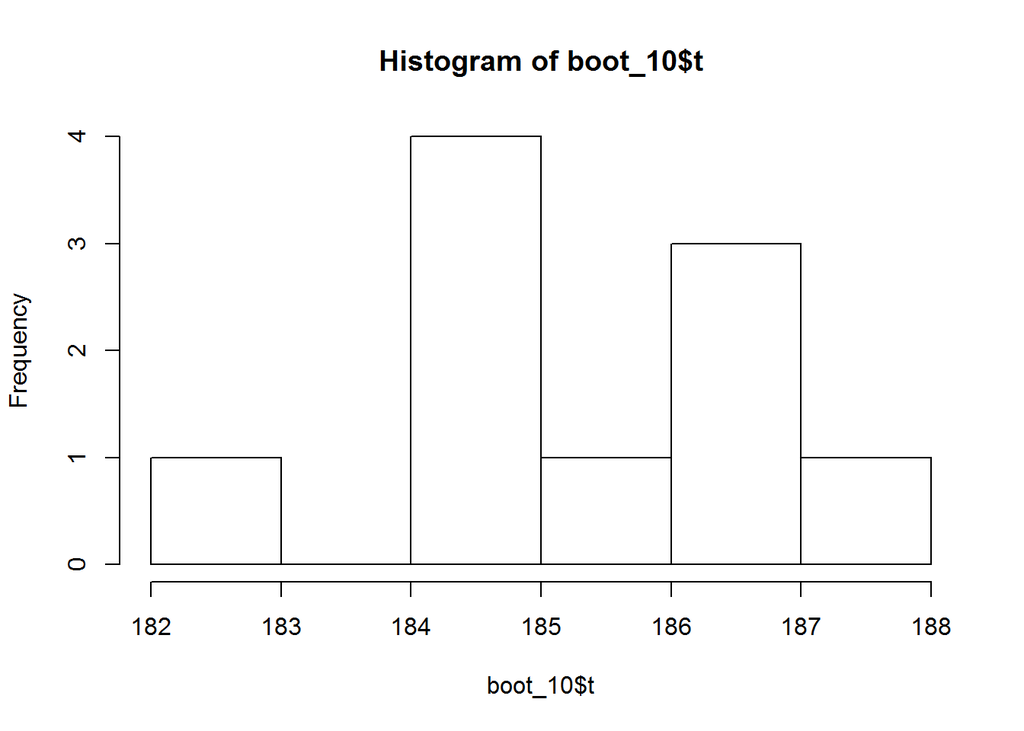

```r
hist(boot_10$t)
```

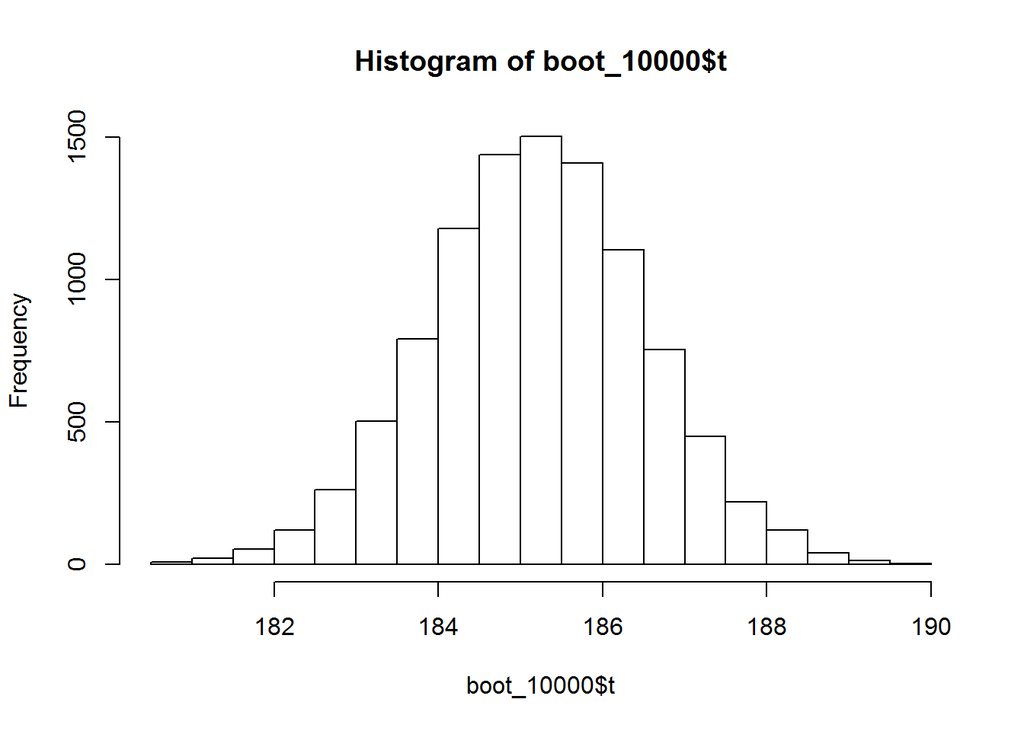

```r
boot_10000 <- boot(flip_v, mean_fun, R = 10000)
hist(boot_10000$t)
```

```r
boot_10000
```

```
##
## ORDINARY NONPARAMETRIC BOOTSTRAP
##
##
## Call:
## boot(data = flip_v, statistic = mean_fun, R = 10000)
##
##
## Bootstrap Statistics :
##     original       bias    std. error
## t1* 185.2273 -0.002672727     1.31017
```

5. Find the confidence interval based on the sampling distribution using function boot.ci()

```r
penguin_ci <- boot.ci(boot_10000, conf = 0.95, type = "perc")
penguin_ci
```

```
## BOOTSTRAP CONFIDENCE INTERVAL CALCULATIONS
## Based on 10000 bootstrap replicates
##
## CALL :
## boot.ci(boot.out = boot_10000, conf = 0.95, type = "perc")
##
## Intervals :
## Level     Percentile
## 95%   (182.6, 187.8 )
## Calculations and Intervals on Original Scale
```

### Non-Linear Least Squares

2. Look at data

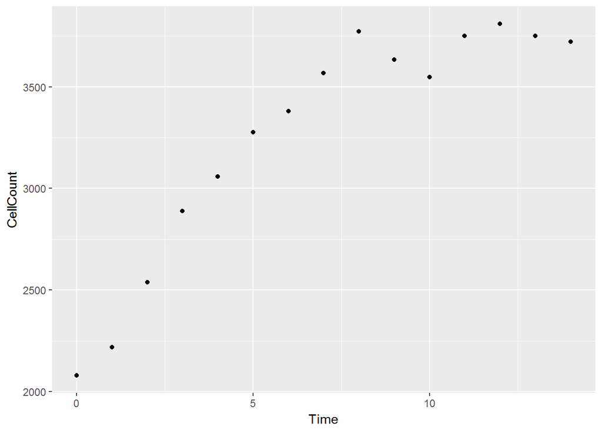

```r
ggplot(CellGrowth, aes(x = Time, y = CellCount)) +
  geom_point()
```

C(t) = A/1+Be^=rt  
B= K-C0/C0

Estimate for carrying capacity (k): ~3700 Estimate for C0: ~2000 Estimate for B: (3700 - 2000)/2000 : ~0.85

Create a linear model between the ln of CellCount and Time for the first 5 observations (these look like they might follow exponential growth). The Slope of that line is an estimate for the growth rate constant.

```r
r_est <- lm(log(CellGrowth$CellCount [1:5]) ~CellGrowth$Time[1:5]) #only using observations 1-5
r_est
```

```
##
## Call:
## lm(formula = log(CellGrowth$CellCount[1:5]) ~ CellGrowth$Time[1:5])
##
## Coefficients:
##          (Intercept)  CellGrowth$Time[1:5]
##               7.6286                0.1035
```

```r
#From this we have a guess at r: 0.1035
```

Estimate for A (k): ~3700 Estimate for C0: ~2000 Estimate for B: ~0.85 Estimate for r: 0.1035

NLS for estimating parameter values for logistic growth, starting with our estimates for A, B and r.

C = A/(1+Be^-rt)

```r
cell_fit <- nls(CellCount ~ A/(1+B*exp(-r*Time)),
                data = CellGrowth,
                start = list(A = 3700, B = 0.85, r = 0.1035), #starting values
                trace = TRUE)
```

```
## 7996304 :  3700.0000    0.8500    0.1035
## 7595140 :  3293.8084442    0.6431423    0.1437013
## 5307698 :  3197.140704    0.595545    0.215801
## 1494838 :  3436.8256143    0.7253421    0.3060712
## 88027.23 :  3802.4852184    0.9209577    0.3501814
## 87191.74 :  3806.5481869    0.9228920    0.3435714
## 87187.73 :  3805.8080711    0.9233090    0.3443107
## 87187.7 :  3805.8993927    0.9232887    0.3442454
## 87187.7 :  3805.8912348    0.9232910    0.3442515
```

The left column shows the sum of squares values if the values on the right are used. It converges at the bottom down to the thousandeths.

Now I will tell r what these paremeters we found are.

```r
A <- coef(cell_fit)[1]
B <- coef(cell_fit)[2]
r <- coef(cell_fit)[3]
```

The ony variable we don’t have now is time, so we will make a time sequence (from 0 - 20 hours, and I want there to be 100 values within that). Then I’m going to plug that into my model to find the predicted cell population size.

```r
time_seq <- seq(0, 20, length =100) #this will give me a range of values from 0 to 20 with 100 values evenly spaced

cell_pred <- A/(1 + B*exp(-r*time_seq))

pred_df <- data.frame(time_seq, cell_pred)
```

Create a graph of the original data + predictive model line

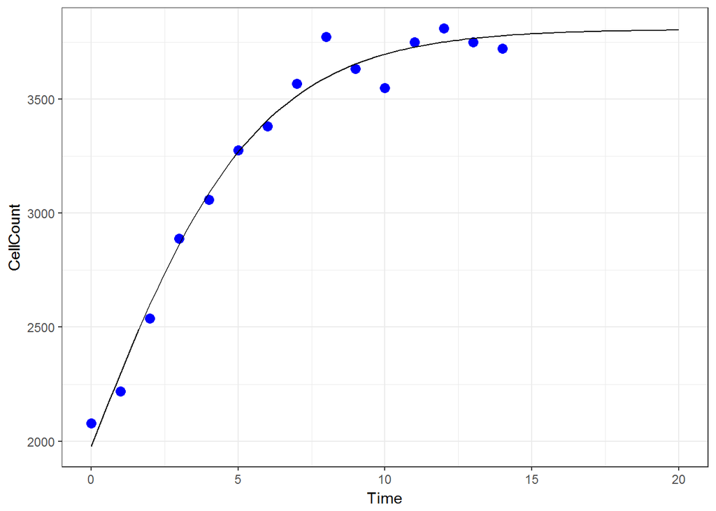

```r
ggplot(CellGrowth, aes( x = Time, y = CellCount)) +
  geom_point( color = "blue", size = 3) +
  theme_bw() +
  geom_line(data = pred_df, aes(x = time_seq, y = cell_pred))
```